# Visualisation with ggplot

Etienne Côme

November, 6 2026

## Visualisation ?

“Transformation of the symbolic into the geometric”  
[McCormick et al. 1987]

“… finding the artificial memory that best supports our natural means of perception.”  
[Bertin 1967]

“The use of computer-generated, interactive, visual representations of data to amplify cognition.”  
[Card, Mackinlay, & Shneiderman 1999]

## Why visualize?

### Integrating the human in the loop

- Answer questions or find questions?
- Making decisions
- Putting data in context
- Amplify the memory
- Graphic calculation
- Find schematics and patterns
- Presenting arguments

## Why visualize?

### Analyze :

- Developing and criticizing hypotheses
- Discovering errors
- Find patterns

### Communicate

- Sharing and convincing
- Collaborate and review

## Anscombe quartet

| g | mean_x | mean_y | sd_x | sd_y |
| --- | --- | --- | --- | --- |
| 1 | 9 | 7.500909 | 3.316625 | 2.031568 |
| 2 | 9 | 7.500909 | 3.316625 | 2.031657 |
| 3 | 9 | 7.500000 | 3.316625 | 2.030424 |
| 4 | 9 | 7.500909 | 3.316625 | 2.030578 |

## Anscombe quartet

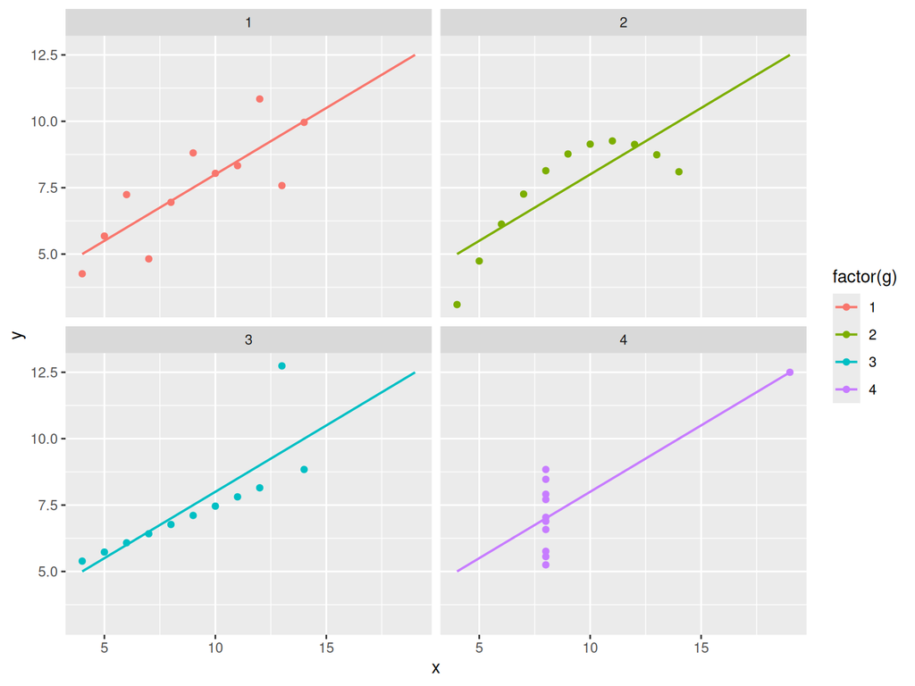

## Cholera map (John Snow)

[figure not shown]

# Visualization

## Visual channels

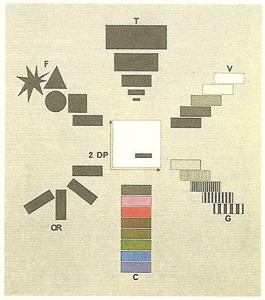

#### Bertin Jacques, Sémiologie graphique, Paris, Mouton/Gauthier-Villars, 1967.

## Visual channels

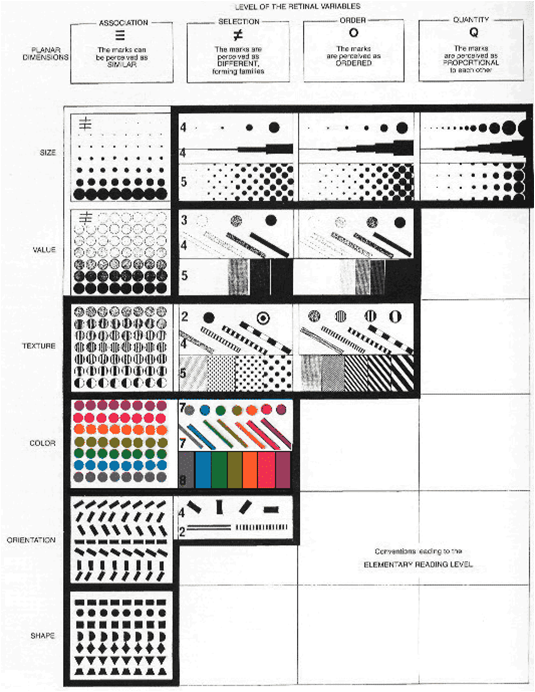

#### Bertin Jacques, Sémiologie graphique, Paris, Mouton/Gauthier-Villars, 1967.

## Marks // visuals channels

### Marks :

graphical building blocks

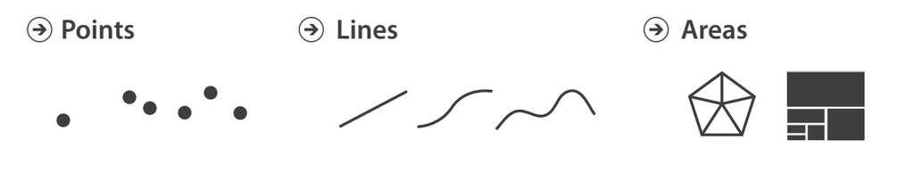

### Visual channels :

The visual properties that varie

## Marks, visual channels

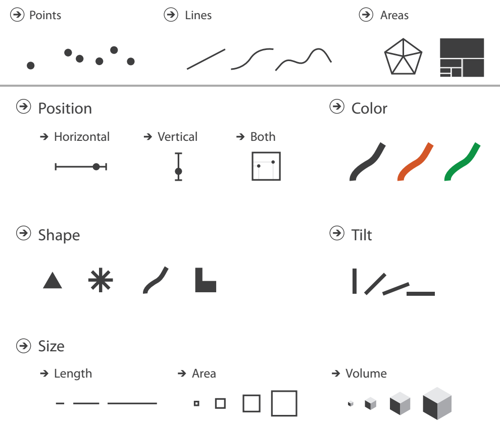

## Marks, visual channels

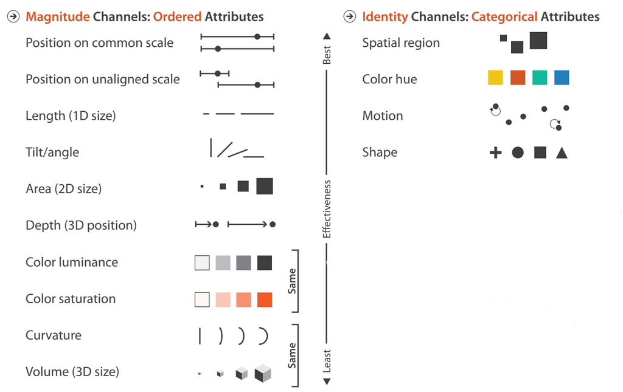

All channels are not equals

## Marks, visual channels

#### The best channels depend on the feature type (continuous, categorical, ordinal,…)

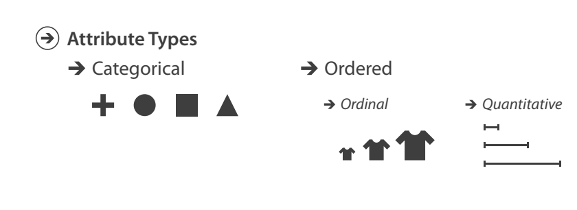

## Marks, visual channels

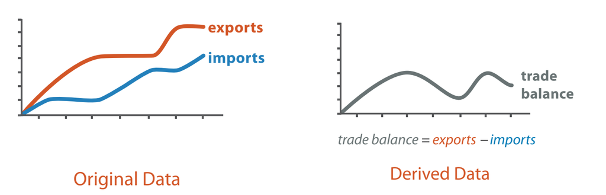

The interesting part is not already available

## pre-attentive processing

### How many 3 ?

1281768756138976546984506985604982826762 9809858458224509856458945098450980943585 9091030209905959595772564675050678904567 8845789809821677654876364908560912949686

## pre-attentive processing

### How many 3 ?

1281768756138976546984506985604982826762 9809858458224509856458945098450980943585 9091030209905959595772564675050678904567 8845789809821677654876364908560912949686

## pre-attentive processing

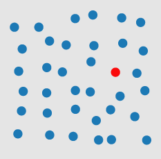

## pre-attentive processing

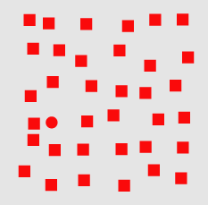

## pre-attentive processing

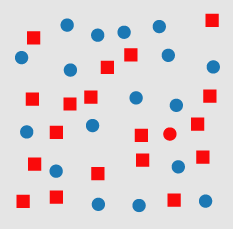

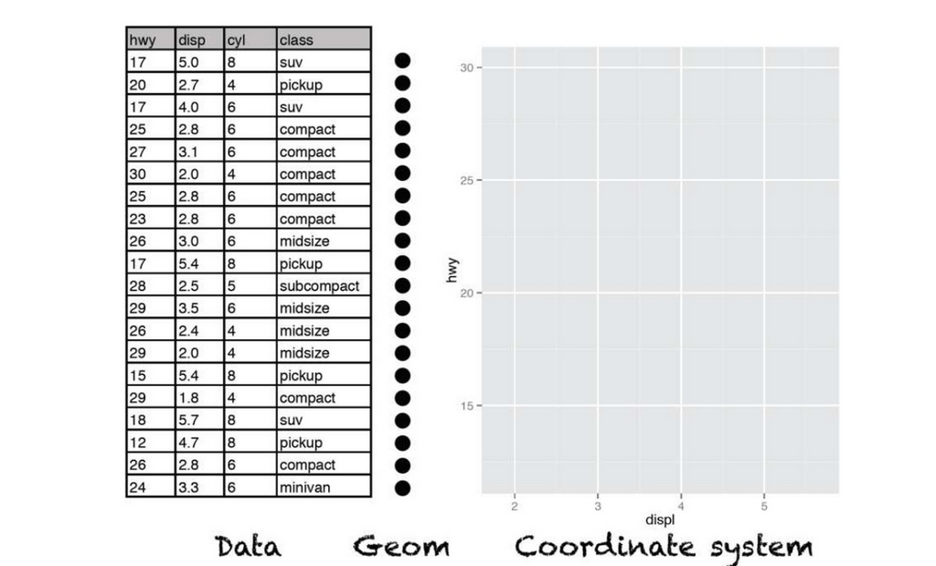

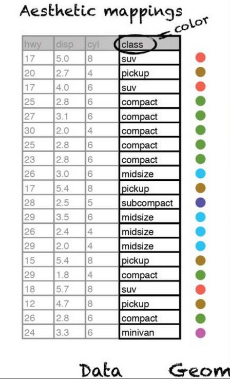

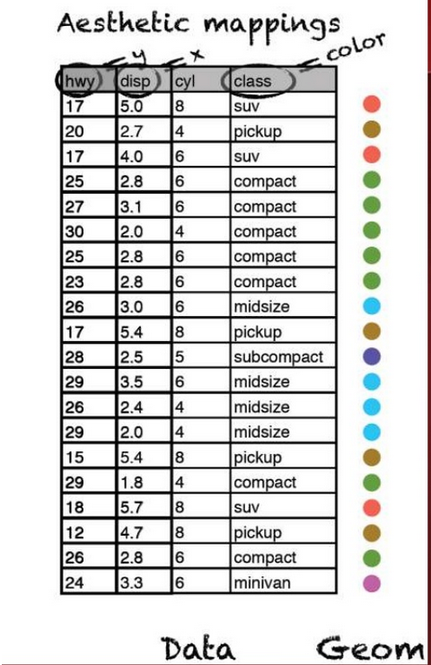

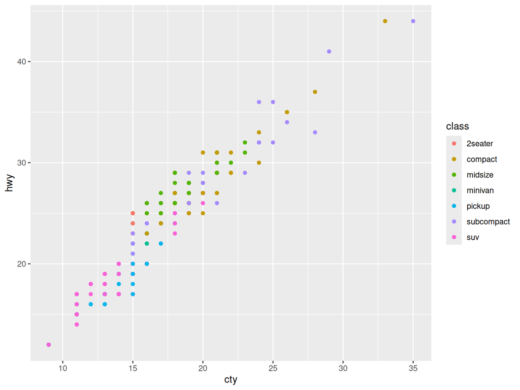

```r
library(ggplot2)
ggplot(mpg)+geom_point(aes(x=cty,y=hwy,color=class))
```

# Questions ? Features types ?

# continuous ? discretes ? ordinals ? temporal ? spatials ?

# Some categories

# The bar chart

## le bar chart

```r
library(rjson)
library(dplyr)
?mpg
```

#### dataset mpg

- manufacturer.
- model.
- displ. engine displacement, in litres
- …

## The bar chart

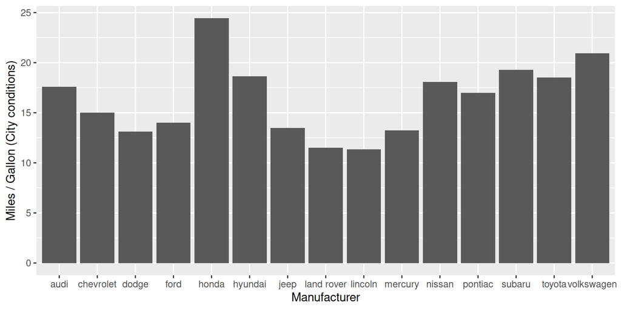

```r
m_cty = mpg %>% group_by(manufacturer) %>% summarize(mcty=mean(cty))
ggplot(data=m_cty)+
  geom_bar(aes(x=manufacturer,y=mcty),stat = 'identity')+
  scale_x_discrete("Manufacturer")+
  scale_y_continuous("Miles / Gallon (City conditions)")
```

## Order ?

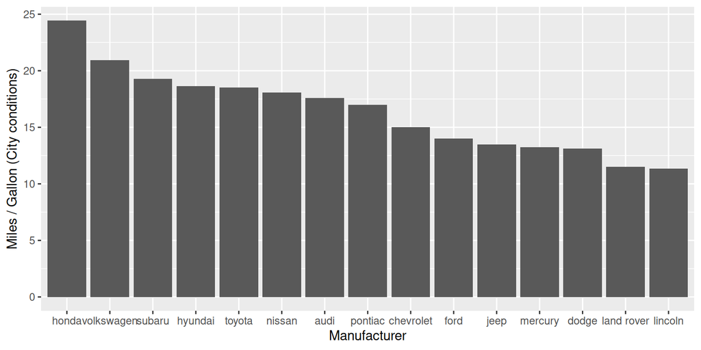

```r
m_cty_ordered = m_cty %>% arrange(desc(mcty)) %>%
  mutate(manufacturer=factor(manufacturer,levels=manufacturer))
ggplot(data=m_cty_ordered)+
  geom_bar(aes(x=manufacturer,y=mcty),stat = 'identity')+
  scale_x_discrete("Manufacturer")+
  scale_y_continuous("Miles / Gallon (City conditions)")
```

## Horizontal ?

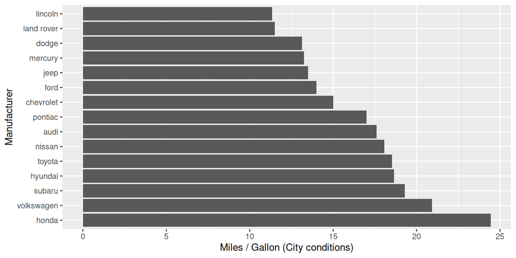

```r
ggplot(data=m_cty_ordered)+
  geom_bar(aes(x=manufacturer,y=mcty),stat = 'identity')+
  scale_x_discrete("Manufacturer")+
  scale_y_continuous("Miles / Gallon (City conditions)")+
  coord_flip()
```

# The line :

# 1 numeric variable

# with respect

# to time

# Vélib’ data :

```r
url="./data/sp_Lyon.json"
library(dplyr)
# read some data
data=fromJSON(file=url)
# to data.frame
extract = function(x){
  data.frame(id=x$'_id',
             time= x$download_date,
             nbbikes = x$available_bikes )
  }
st_tempstats.df=do.call(rbind,lapply(data,extract))
tempstats.df=st_tempstats.df |> group_by(time) |> summarise(nbbikes = sum(nbbikes))
```

## Time, natural order

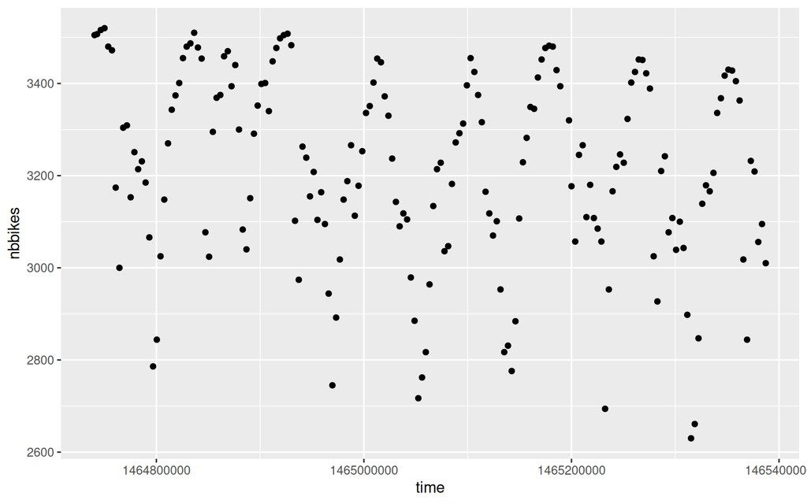

```r
ggplot(data=tempstats.df,aes(x=time,y=nbbikes))+geom_point()
```

## Time, natural order

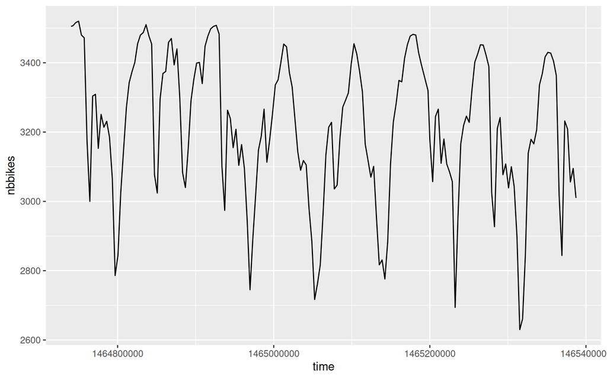

```r
ggplot(data=tempstats.df,aes(x=time,y=nbbikes))+geom_line()
```

## Aspect ratio

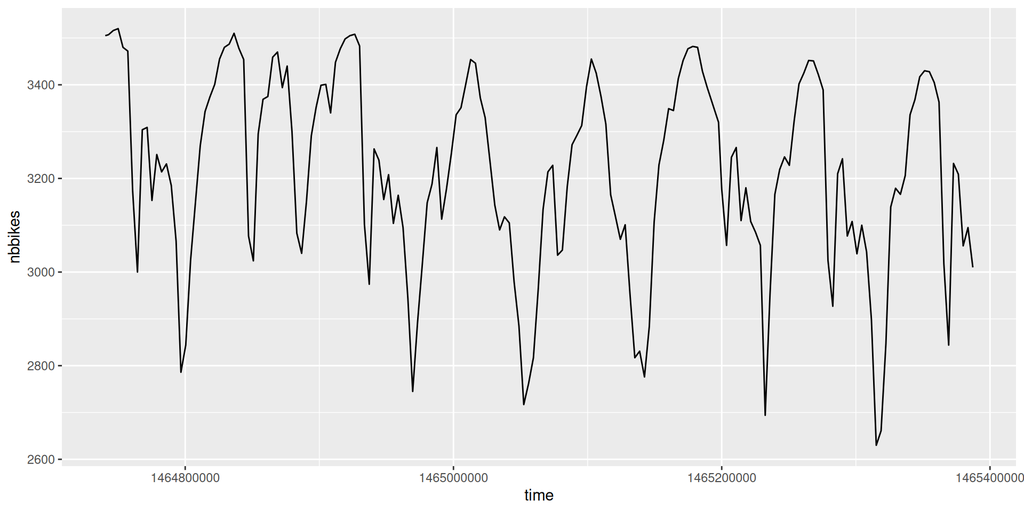

```r
ggplot(data=tempstats.df,aes(x=time,y=nbbikes))+geom_line()
```

## Aspect ratio

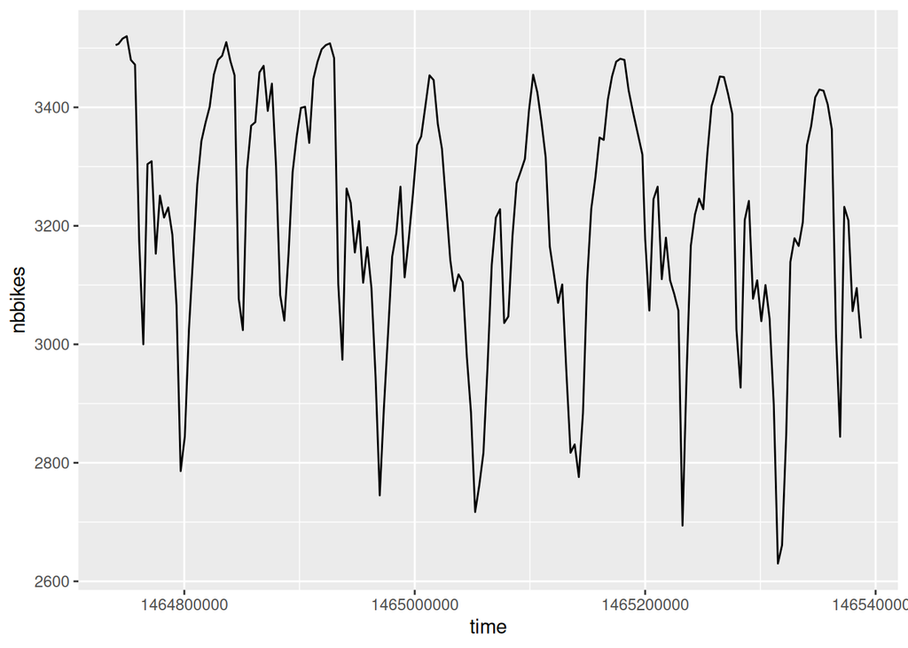

```r
ggplot(data=tempstats.df,aes(x=time,y=nbbikes))+geom_line()
```

## Aspect ratio

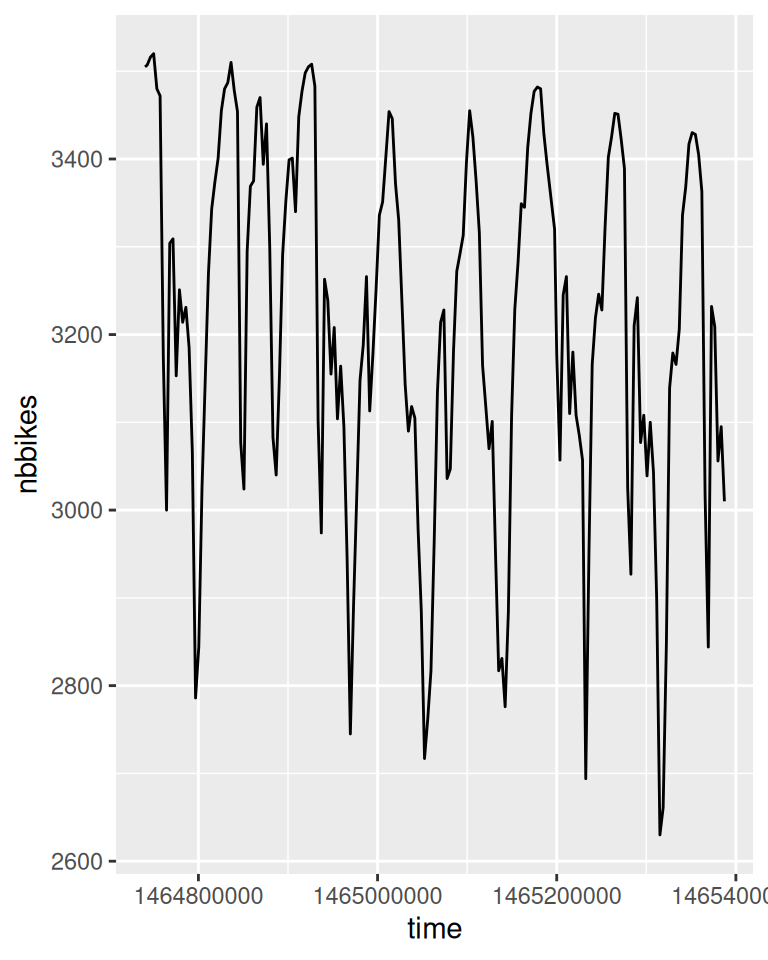

```r
ggplot(data=tempstats.df,aes(x=time,y=nbbikes))+geom_line()
```

## Aspect ratio, 45°

Heuristic: use the aspect ratio that results in an average line slope of 45°.

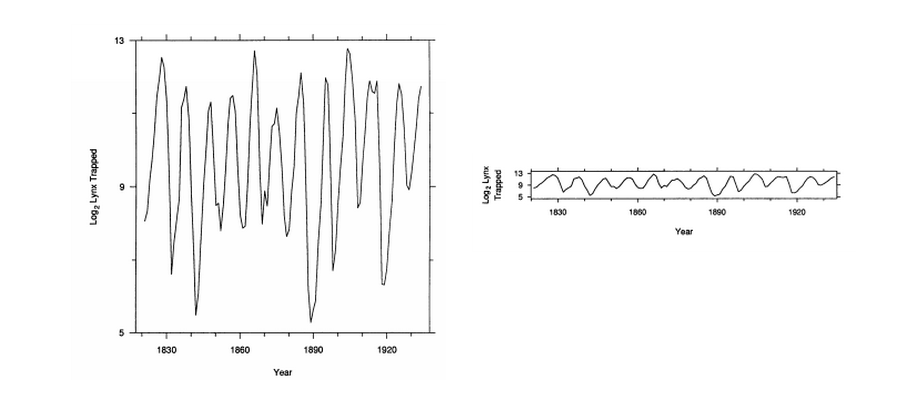

#### Cleveland, William S., Marylyn E. McGill, and Robert McGill. “The shape parameter of a two-variable graph.” Journal of the American Statistical Association 83.402 (1988): 289-300.

## Area + Scale

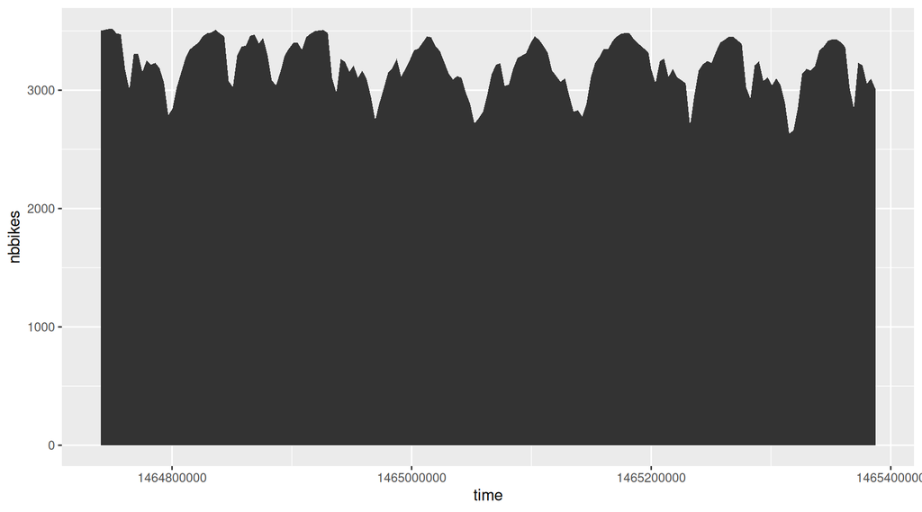

```r
ggplot(data=tempstats.df,aes(x=time,y=nbbikes))+geom_area()
```

## Point of view

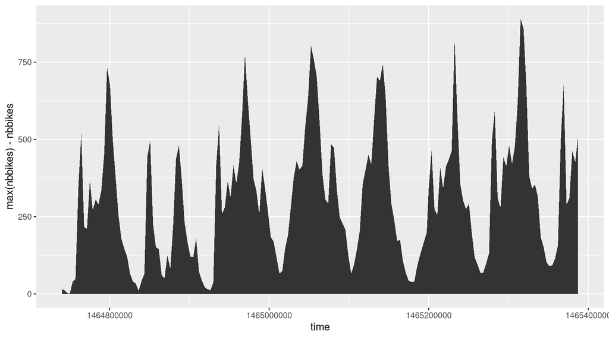

```r
ggplot(data=tempstats.df,aes(x=time,y=max(nbbikes)-nbbikes))+
  geom_area()
```

# 1 numeric variable

# with respect

# to time

# + categories

## Velib data per stations

```r
# read data and pre-processing
url = "./data/sp_Lyon.json"
data=fromJSON(file=url)
extract = function(x){
  data.frame(id=x$'_id',
             time= x$download_date,
             nbbikes = x$available_bikes )
  }
st_tempstats.df=do.call(rbind,lapply(data,extract))
sel = st_tempstats.df %>% select(id) %>% unique() %>% sample_n(8) %>% pull()
# selection de quelques stations
st_tempstats_sub.df = st_tempstats.df %>%
  filter(id %in% sel)
```

## Multiple line charts

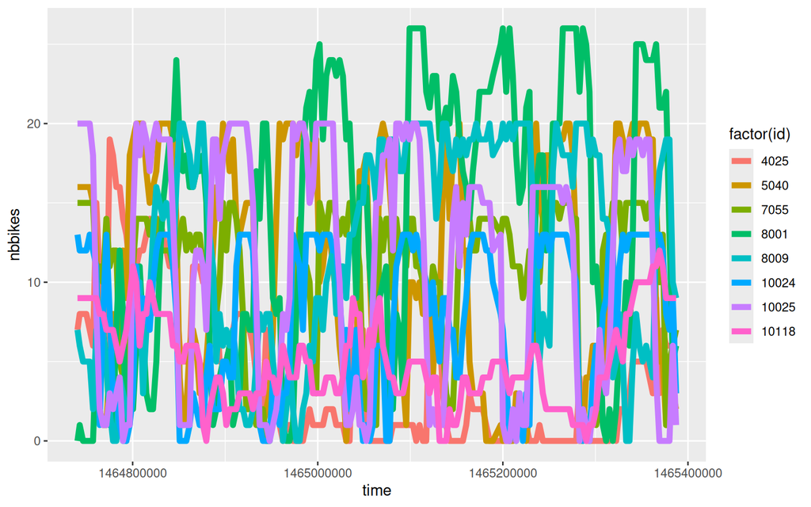

```r
ggplot(data=st_tempstats_sub.df)+
  geom_line(aes(x=time,y=nbbikes,group=id,color=factor(id)),size=2)
```

## Small multiples

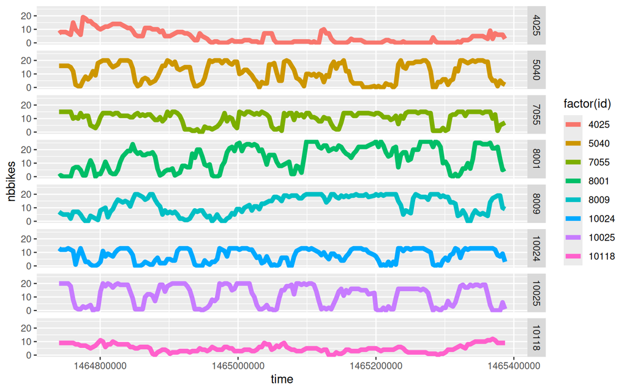

```r
ggplot(data=st_tempstats_sub.df)+
  geom_line(aes(x=time,y=nbbikes,group=id,color=factor(id)),size=2)+
  facet_grid(id ~ .)
```

# 2 numeric features

# + categories

## Scatter plot + colors

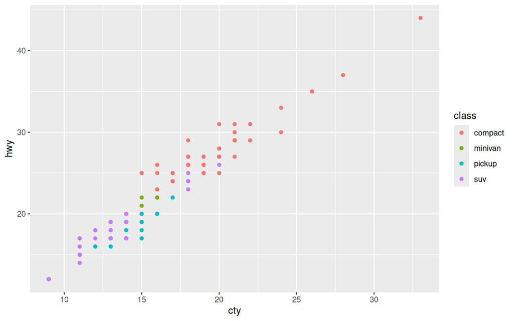

```r
mpg_su = mpg %>%
  filter(class %in% c('compact','suv','pickup','minivan'))
ggplot(mpg_su)+geom_point(aes(x=cty,y=hwy,color=class))
```

## Scatter plot + symbols

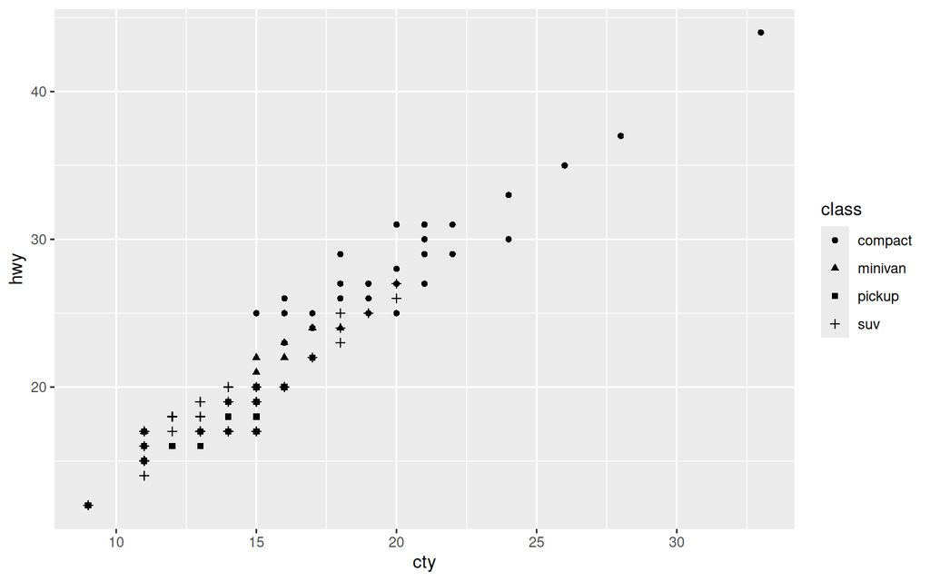

```r
mpg_su = mpg %>%
  filter(class %in% c('compact','suv','pickup','minivan'))
ggplot(mpg_su)+geom_point(aes(x=cty,y=hwy,shape=class))
```